# Assignment 4

In this assignment, you'll combine the assignment 3 data set with nutrition data from the [USDA Food Composition Databases](https://ndb.nal.usda.gov/ndb/search/list). The CSV file `fresh.csv` contains the fresh fruits and vegetables data you extracted in assignment 3.

The USDA Food Composition Databases have a [documented](https://ndb.nal.usda.gov/ndb/doc/index) web API that returns data in JSON format . You need a key in order to use the API. Only 1000 requests are allowed per hour, so it would be a good idea to use [caching](https://pypi.python.org/pypi/requests-cache).

[Sign up for an API key here](https://api.data.gov/signup/). The key will work with any Data.gov API. You may need the key again later in the quarter, so make sure you save it.

These modules may be useful:

- [requests](http://docs.python-requests.org/en/master/user/quickstart/)
- [requests_cache](https://pypi.python.org/pypi/requests-cache)
- [urlparse](https://docs.python.org/2/library/urlparse.html)
- [pandas](http://pandas.pydata.org/pandas-docs/stable/)

```python
from urllib2 import Request, urlopen
import pandas as pd
import numpy as np
import json
from string import digits
from matplotlib import pyplot as plt
plt.style.use('ggplot')
from pandas.io.json import json_normalize
%matplotlib inline
```

**Exercise 1.1.** Read the [search request documentation](https://ndb.nal.usda.gov/ndb/doc/apilist/API-SEARCH.md), then write a function called `ndb_search()` that makes a search request. The function should accept the search term as an argument. The function should return the search result items as a list (for 0 items, return an empty list).

Note that the search url is: `https://api.nal.usda.gov/ndb/search`

As an example, a search for `"quail eggs"` should return this list:

```
[{u'ds': u'BL',
  u'group': u'Branded Food Products Database',
  u'name': u'CHAOKOH, QUAIL EGG IN BRINE, UPC: 044738074186',
  u'ndbno': u'45094707',
  u'offset': 0},
 {u'ds': u'BL',
  u'group': u'Branded Food Products Database',
  u'name': u'L&W, QUAIL EGGS, UPC: 024072000256',
  u'ndbno': u'45094890',
  u'offset': 1},
 {u'ds': u'BL',
  u'group': u'Branded Food Products Database',
  u'name': u'BUDDHA, QUAIL EGGS IN BRINE, UPC: 761934535098',
  u'ndbno': u'45099560',
  u'offset': 2},
 {u'ds': u'BL',
  u'group': u'Branded Food Products Database',
  u'name': u'GRAN SABANA, QUAIL EGGS, UPC: 819140010103',
  u'ndbno': u'45169279',
  u'offset': 3},
 {u'ds': u'BL',
  u'group': u'Branded Food Products Database',
  u'name': u"D'ARTAGNAN, QUAIL EGGS, UPC: 736622102630",
  u'ndbno': u'45178254',
  u'offset': 4},
 {u'ds': u'SR',
  u'group': u'Dairy and Egg Products',
  u'name': u'Egg, quail, whole, fresh, raw',
  u'ndbno': u'01140',
  u'offset': 5}]
```

As usual, make sure you document and test your function.

```python
def ndb_search(food):
        a = []
        b = []
        keys = 'https://api.nal.usda.gov/ndb/search/?format=json&q={}&sort=n&max=25&offset=0&api_key=jCE54mSBjMcyzAtGWnQCfH8yr1lh35cUlcxC3y8h'.format(food)
        reequium = Request(keys)
        response = urlopen(reequium)
        old = json.loads(response.read())
        checked = True if 'errors' in old else False
        if(checked == True):
            return b
        else:
            a.append(old.copy())
            return a
ffs = ndb_search('watermelon,_raw')
```

[output not shown]

**Exercise 1.2.** Use your search function to get NDB numbers for the foods in the `fresh.csv` file. It's okay if you don't get an NDB number for every food, but try to come up with a strategy that gets most of them. Discuss your strategy in a short paragraph.

Hints:

- The foods are all raw and unbranded.
- You can test search terms with the [online search page](https://ndb.nal.usda.gov/ndb/search/list).
- You can convert the output of `ndb_search()` to a data frame with `pd.DataFrame()`.
- The string methods for [Python](https://docs.python.org/2/library/stdtypes.html#string-methods) and [Pandas](http://pandas.pydata.org/pandas-docs/stable/text.html#method-summary) are useful here. It's okay if you use *simple* regular expressions in the Pandas methods, although this exercise can be solved without them.
- You can merge data frames that have a column in common with `pd.merge()`.

```python
le = pd.DataFrame.from_csv('/Users/ryanbrady/Desktop/141hw/fresh.csv',header = 0,index_col= 0)
abc = le.iloc[0:,4]
abcs = [abc[i] + ',_raw' for i in range(len(abc))]
searched = [ndb_search(i) for i in abcs]
```

[output not shown]

```python
list2 = [x for x in searched if x != []]
list2

a=[]
[a.append(list2[i][0]['list']['item']) for i in range(len(list2))]
print ''
```

[output not shown]

[output cut: 310 more lines]

[output not shown]

```python
import itertools
merged = list(itertools.chain(*a))
```

```python
cheese = pd.DataFrame(merged)
dfsub = df[(df.group == "Fruits and Fruit Juices") | (df.group == "Vegetables and Vegetable Products")]
```

[output not shown]

[output cut: 47 more lines]

```python
dfsub['name'] = dfsub['name'].str.partition(', raw')[0]
```

```python
newdf = dfsub.drop_duplicates('name')
newdf = newdf.assign(newindex = range(len(newdf)))
q = newdf.index.values



newdf['name'] = newdf['name'].str.lower()
newdf['name'] = newdf['name'].str.partition(', raw')
```

[output not shown]

[output cut: 28 more lines]

For this problem I saw that most of the fruits and vegetables were followed by ,raw so I got rid of many extra products by searching for raw fruits and vegetables, I then subsetted the data frame based on if it was in the group fruits and juices or vegetables and veg products.

**Exercise 1.3.** Read the [food reports V2 documentation](https://ndb.nal.usda.gov/ndb/doc/apilist/API-FOOD-REPORTV2.md), then write a function called `ndb_report()` that requests a *basic* food report. The function should accept the NDB number as an argument and return the list of nutrients for the food.

Note that the report url is: `https://api.nal.usda.gov/ndb/V2/reports`

For example, for `"09279"` (raw plums) the first element of the returned list should be:

```
{u'group': u'Proximates',
 u'measures': [{u'eqv': 165.0,
   u'eunit': u'g',
   u'label': u'cup, sliced',
   u'qty': 1.0,
   u'value': u'143.93'},
  {u'eqv': 66.0,
   u'eunit': u'g',
   u'label': u'fruit (2-1/8" dia)',
   u'qty': 1.0,
   u'value': u'57.57'},
  {u'eqv': 151.0,
   u'eunit': u'g',
   u'label': u'NLEA serving',
   u'qty': 1.0,
   u'value': u'131.72'}],
 u'name': u'Water',
 u'nutrient_id': u'255',
 u'unit': u'g',
 u'value': u'87.23'}
```

Be sure to document and test your function.

```python
def ndb_report(ndb):
    urls = 'https://api.nal.usda.gov/ndb/V2/reports?ndbno={}&type=b&format=json&api_key=jCE54mSBjMcyzAtGWnQCfH8yr1lh35cUlcxC3y8h'.format(ndb)

    reequium = Request(urls)
    response = urlopen(reequium)
    old = json.loads(response.read())
    return old['foods'][0]['food']['nutrients'][3]['value']
cheeil = ndb_report('09279')
```

```
u'0.28'
```

```python
ok[2]
```

```
{u'group': u'Proximates',
 u'measures': [{u'eqv': 165.0,
   u'eunit': u'g',
   u'label': u'cup, sliced',
   u'qty': 1.0,
   u'value': u'1.15'},
  {u'eqv': 66.0,
   u'eunit': u'g',
   u'label': u'fruit (2-1/8" dia)',
   u'qty': 1.0,
   u'value': u'0.46'},
  {u'eqv': 151.0,
   u'eunit': u'g',
   u'label': u'NLEA serving',
   u'qty': 1.0,
   u'value': u'1.06'}],
 u'name': u'Protein',
 u'nutrient_id': u'203',
 u'unit': u'g',
 u'value': u'0.70'}
```

```python
newdf
```

[output not shown]

```python
f = []
[f.append(newdf['ndbno'][i].encode('utf-8')) for i in q]
```

[output not shown]

```python
g = []
[g.append(ndb_report(f[i])) for i in range(len(f))]
```

```
[u'0.15',
 u'0.19',
 u'0.31',
 u'0.31',
 u'0.30',
 u'0.28',
 u'0.65',
 u'1.17',
 u'0.12',
 u'0.39',
 u'0.26',
 u'0.33',
 u'0.30',
 u'0.32',
 u'0.51',
 u'0.14',
 u'0.49',
 u'0.33',
 u'0.12',
 u'0.10',
 u'0.10',
 u'0.20',
 u'0.20',
 u'0.10',
 u'14.66',
 u'0.93',
 u'0.01',
 u'0.19']
```

```python
kcaldf = newdf.assign(kcal = g)
```

[output not shown]

```python
kcaldf.to_csv('kcal.csv',sep = ',')
kcalz = pd.DataFrame.from_csv('/Users/ryanbrady/Desktop/141hw/kcal.csv',header = 0,index_col= 0)
kcalz['']
```

[output not shown]

```python
kcalz['name'] = kcalz['name'].str.lower()
kcalz
kcalzfix = kcalz.drop(kcalz.index[[2,4,13,22]])
```

```python
newindex = range(len(kcalzfix))
```

```python
indexarefun = kcalzfix.assign(newish = newindex)
kcalzfix2 = indexarefun.drop(indexarefun.index[[15,12]])
```

```python
p = []
for i in range(49):
    for j in kcalzfix2.index:
        if(le['food'][i] in kcalzfix2['name'][j]):
            le['food'][i] = kcalzfix2['name'][j]
```

[output not shown]

```python
q = []
for i in range(46):
    for j in range(63):
        if(newsdf['food'][i] == leex['name'][j]):
            if j not in q:
                 q.append(j)
```

```python
nowd = le.merge(kcalzfix2, left_on=[ 'food'], right_on=[ 'name'])
nowd = nowd.drop('newindex',1)
```

```python
newdf = newdf.assign(protein = g)
```

[output not shown]

```python
nowd = nowd.assign(fat = g)
nowd['fat'] = nowd['fat'].astype(float)
```

```python
f = [str(f[i]) for i in range(len(f))]
for i in range(len(f)):
    if(len(f[i]) == 4):
        f[i] = '0' + f[i]
```

**Exercise 1.4.** Which foods provide the best combination of price, yield, and nutrition? You can use kilocalories as a measure of "nutrition" here, but more a detailed analysis is better. Use plots to support your analysis.

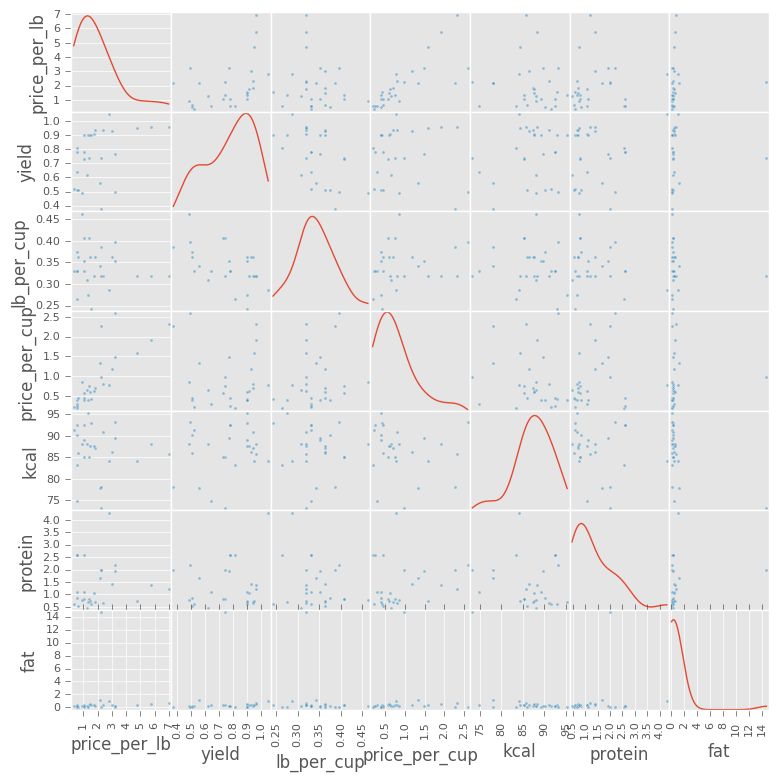

```python
from pandas.tools.plotting import scatter_matrix
caldf = nowd[['price_per_lb', 'yield','lb_per_cup','price_per_cup','kcal','protein','fat']]
_ = scatter_matrix(caldf,figsize=(9,9),diagonal='kde')
```

Looking at the scatter plot we see that there is a slight relationship between protein and kcals, as well as kcals and price_per_cup. We fail to see any relationship in fats do to avocadoes having such a high fat level. We can take another look at the scatters without avocadoes to see its relationships.

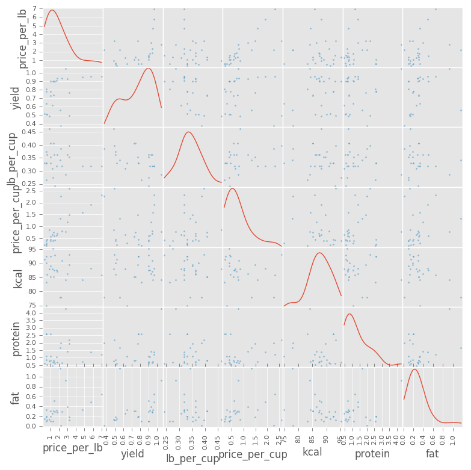

```python
noavocat = caldf.drop(caldf.index[[24]])
_ = scatter_matrix(noavocat,figsize=(9,9),diagonal='kde')
```

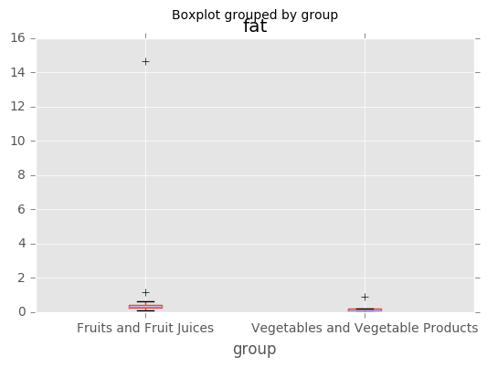

```python
nowd.boxplot(column = 'fat', by = 'group')
```

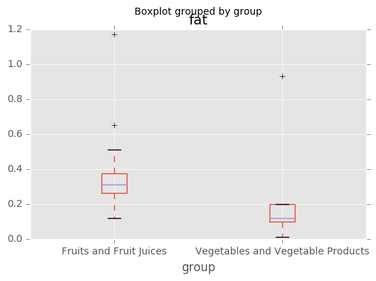

```python
noavocado =  nowd.drop(nowd.index[[24]])

noavocado.boxplot(column = 'fat', by = 'group')
```

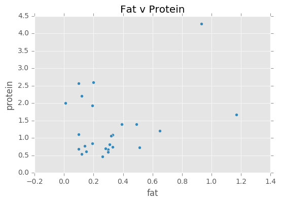

```python
_ = noavocado.plot('fat','protein',kind='scatter',title = 'Fat v Protein')
```

We see a linear trend for a cluster of foods. To see whether this is a relationship we will look at the scatter to see what are vegetables and what are fruits.

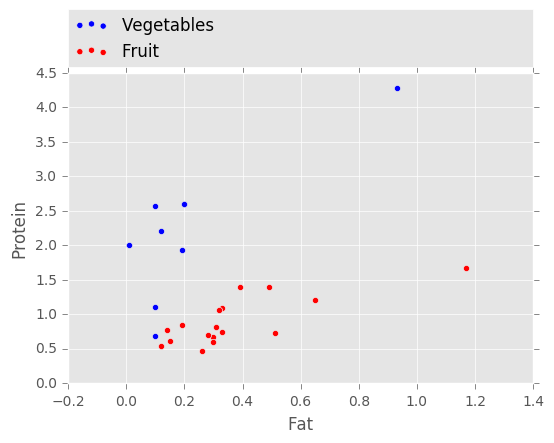

```python
veg = noavocado[noavocado['group'] == 'Vegetables and Vegetable Products']
fruit = noavocado[noavocado['group'] == 'Fruits and Fruit Juices']
plt.scatter(veg['fat'],veg['protein'],label = 'Vegetables')

plt.scatter(fruit['fat'],fruit['protein'],c = 'r',label = 'Fruit')
plt.legend(bbox_to_anchor=(0., 1.02, 1., .102), loc=3,
           ncol=1, mode="expand", borderaxespad=0.)
plt.xlabel('Fat')
plt.ylabel('Protein')
```

From this plot it appears while a fruit's fat and protein have a linear positive relationship, vegetables does not have that same relationship.

# Protein

In this next part we will look at the relationship between protein, kcals, and price per cup.

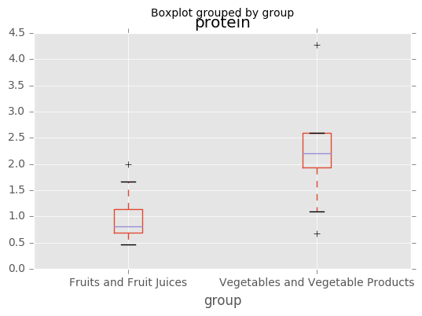

```python
nowd.boxplot(column = 'protein', by = 'group')
```

From the boxplot vegetables clearly contain more protein than fruits. The bottom whisker for vegetables appears to be in the top quartile of proteins for fruits.

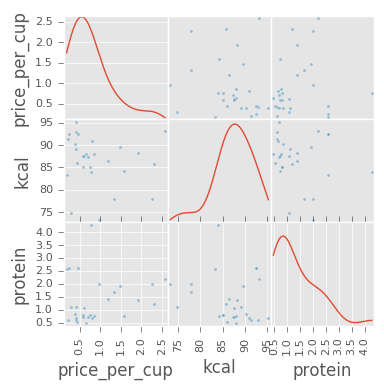

```python
pricevhealth = nowd[['price_per_cup','kcal','protein']]
_= scatter_matrix(pricevhealth,figsize=(4,4),diagonal='kde')
```

# Yield

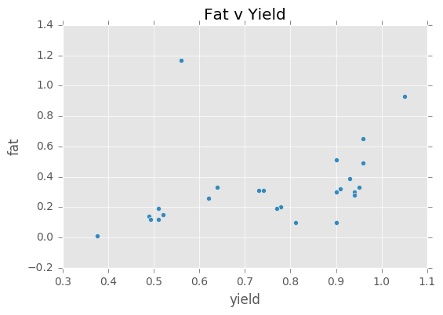

```python
_ = noavocado.plot('yield','fat',kind='scatter',title = 'Fat v Yield')
```

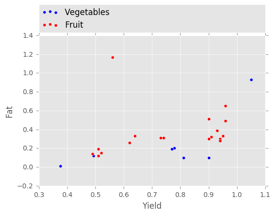

```python
veg = noavocado[noavocado['group'] == 'Vegetables and Vegetable Products']
fruit = noavocado[noavocado['group'] == 'Fruits and Fruit Juices']
plt.scatter(veg['yield'],veg['fat'],label = 'Vegetables')

plt.scatter(fruit['yield'],fruit['fat'],c = 'r',label = 'Fruit')
plt.legend(bbox_to_anchor=(0., 1.02, 1., .102), loc=3,
           ncol=1, mode="expand", borderaxespad=0.)
plt.xlabel('Yield')
plt.ylabel('Fat')
```

There does not appear to be a difference between the relationship of Yield and Fats and whethere the produce is a vegetable or fruit.

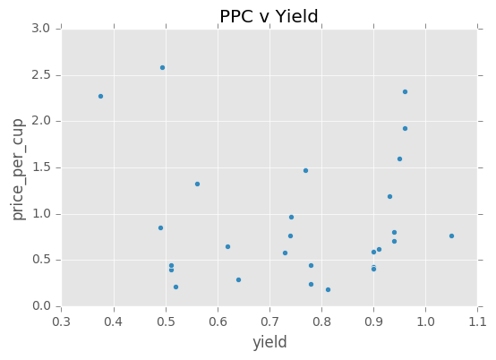

```python
_ = nowd.plot('yield','price_per_cup',kind='scatter',title = 'PPC v Yield')
```

Looking at the plot there does not seem to be a clear relationship between yield and price per cup.

# Conclusions

```
From this report we see that yield seems to have a relationship with fats. This means that attempting to find foods with higher fat content could provide a more substantial meal. When looking for foods that have high fat and protein it seems better to eat fruit, but if one wanted strictly protein, he or she should eat vegetables. Kcals and protein tend to have a small linear relationship so it would be more efficient to eat protein than fats to gain calories. However, it would be more expensive to eat more protein based produce than fattier produce.
```